# ETC5521 Tutorial 2

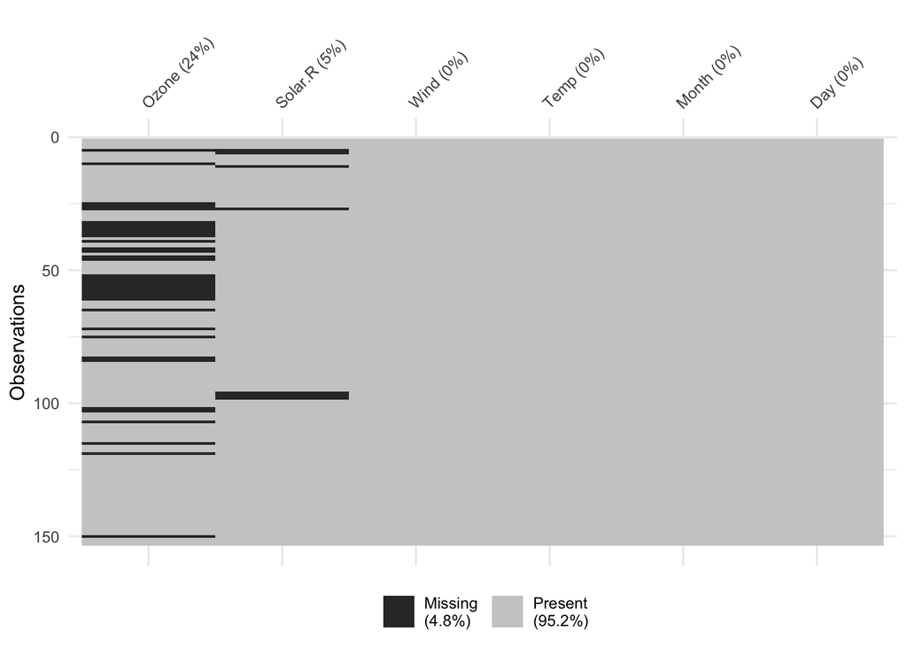

```r
# function 3
vis_miss(airquality)
```

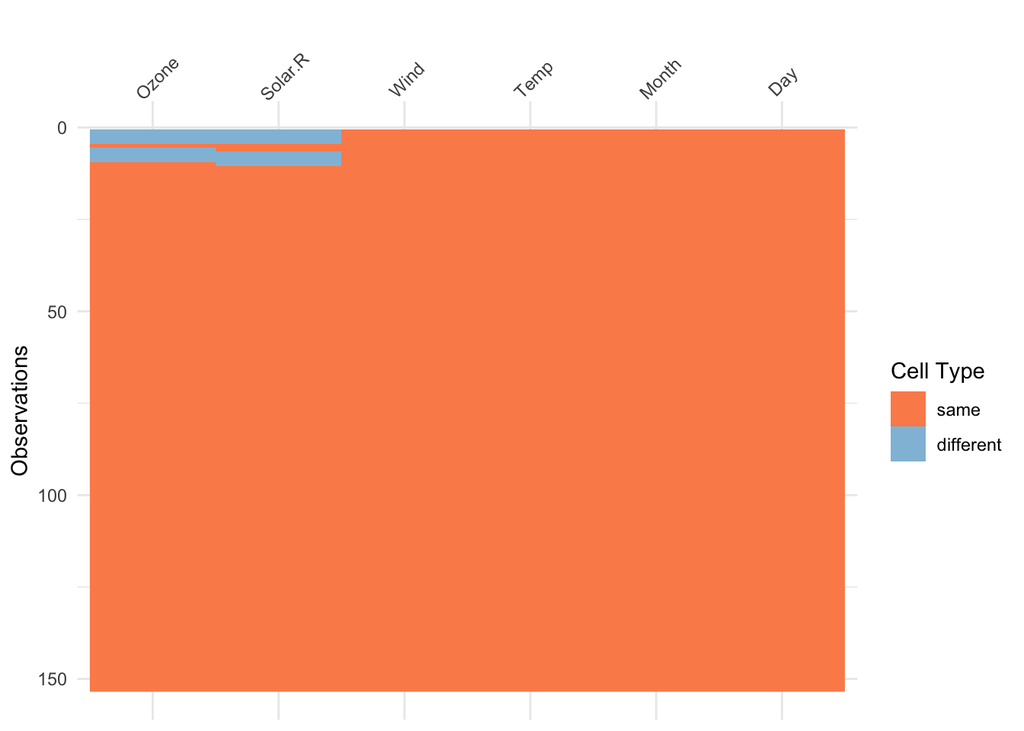

```r
# function 4
aq_diff <- airquality
aq_diff[1:10, 1:2] <- NA
vis_compare(airquality, aq_diff)
```

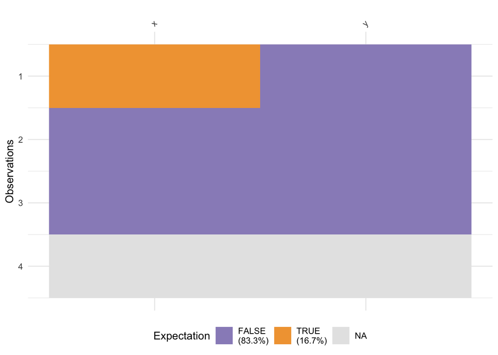

```r
# function 5
dat_test <- tibble::tribble(
            ~x, ~y,
            -1,  "A",
            0,  "B",
            1,  "C",
            NA, NA
            )

vis_expect(dat_test, ~.x == -1)
```

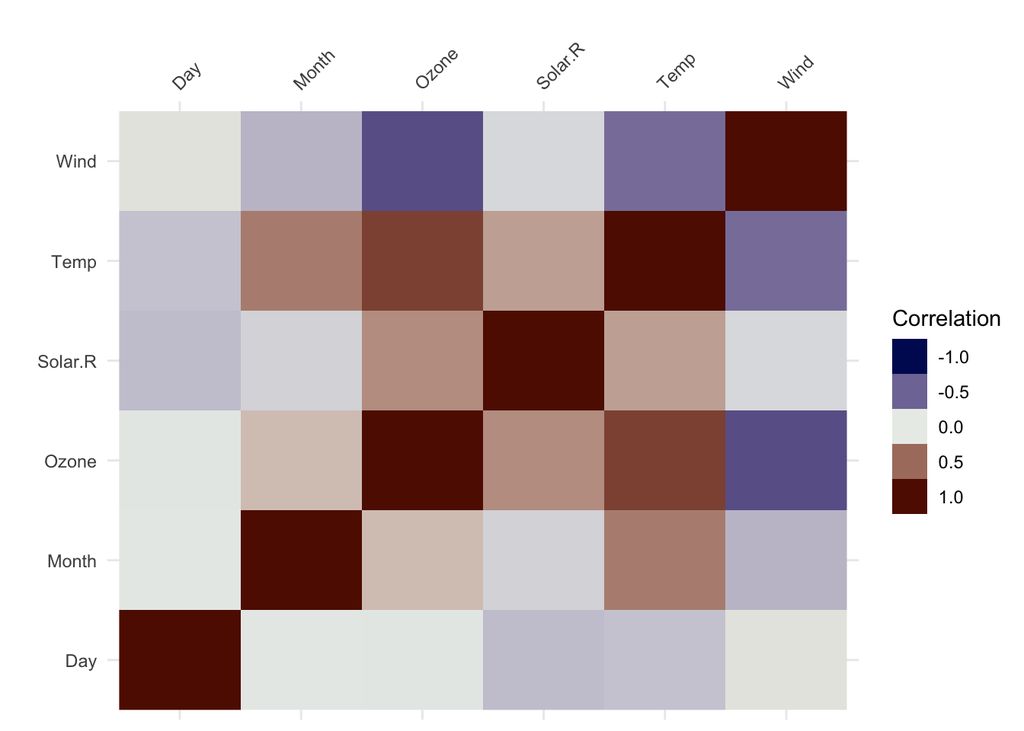

```r
# function 6
vis_cor(airquality)
```

5. The package `DataExplorer` has a high download rate and number of GitHub stars, and also a nice web site at https://boxuancui.github.io/DataExplorer/. The vignette “Introduction to DataExplorer” is a good place to start to learn what the package does. I want you to generate an automatic report to see what it creates, and what the package suggests is important. Use the code below to create the data to use - it does the same thing as the code in the vignette but uses `dplyr` and piping more nicely. Then run the report. It’s not very pretty to read, but there’s a vast amount of very useful information about the data that can help in preparing for its analysis. It’s completely overwhelming, though.
1. What does specifying `y = "arr_delay"` do?
2. Which variables have a lot of missing values?
3. How many engines do planes typically have?
4. What does the scale of the `arr_time`, `dep_time`, `sched_arr_time` and `sched_dep_time` indicate?
5. Which carrier had the most flights?
6. Which type of plane was most common? Why might conclusions about the type of plane be dangerous about to make?
7. What do the QQ plots tell you?
8. `arr_delay` is divided into 6 categories before making some plots. Why do you think the purpose of this is?
9. With your neighbour in the tutorial come up with **one** thing that is a bit surprising to you about this data. Make sure you state what you expected to see, and why what you saw was then a surprise.

```r
# DataExplorer
library(DataExplorer)
library(nycflights13)
library(tidyverse)

# Create a big data set
airlines_all <- flights %>%
  full_join(airlines, by = "carrier") %>%
  full_join(planes, by = "tailnum",
            suffix = c("_flights", "_planes")) %>%
  full_join(airports, by = c("origin"="faa"),
            suffix = c("_carrier", "_origin")) %>%
  full_join(airports, by = c("dest"="faa"),
            suffix = c("_origin", "_dest"))

# Run a report
create_report(airlines_all, y = "arr_delay")
```

**Solution**

1. This is specifying that `arr_delay` is to be treated as a response variable.
2. The variable `speed` is mostly missing. Other variables `engine`, `seats`, `model`, `manufacturer`, `type` and `year_planes` have about 15% missing.
3. Almost all planes have 2 engines. Some have 1, and it seems that some have 3 or 4. The histogram includes these categories which means there must be some planes with 4 engines, but the count is so small that the bar is invisible.
4. These are hours and minutes as four digits, eg 1045 means 10:45am.
5. UA, United Airlines
6. BOEING. It could be dangerous because 15% of observations on this variable are missing. If these **all** belong to one of the other popular types of planes (ie EMBRAER) we may be over-stating the popularity of BOEING.
7. QQ plots are for checking for normal distributions. We can see that none of the variables have normal distributions because noe of these feature points along the straight guide line.
8. Sometimes breaking a numeric variable into pieces and plotting against another variable allows a rough assess associations in a simplified manner. It is often done to assess associations with categorical variables.
9. Here is one example: We might expect that if the departure was delayed then the arrival would be delayed. In the scatterplot of `dep_delay` vs `arr_delay` we don’t see this pattern! There is a subset of flights where there is a strong relationship, and another subset of observations where `dep_delay` is slightly increased at the highest values of `arr_delay`, but for the most part it is flat. That even if there is no departure delay, there is a long arrival delay. This is curious! But there is something strange about this plot, too. It looks like `arr_delay` was treated as a categorical variable, given the regular markings on the horizontal axis.
6. Table 2 summarises the activities of two early phases of the CRISP-DM standard. What does CRISP-DM mean? The implication is that EDA is related to “data understanding” and “data preparation”. Would you agree with this or disagree? Why?

**Solution**

Cross-Industry Standard Process for Data Mining; EDA techniques can be useful for some parts of these stages, for example finding outliers, or examining missing value patterns. Some of these steps are important for effective EDA, too, for example, you need to know what types of variables you have in order to decide what types of plots to make.

7. Table 1 of the paper is summarising CRAN downloads and GitHub activity is hard to read. How are the rows sorted? What is the most important information communicated by the table? In what way(s) might revising this table make it easier to read and digest the most important information?

**Solution**

Most important information is the download rate because the purpose is to know which are the commonly used packages. Sort rows by downloads.

## 👋 Finishing up

Make sure you say thanks and good-bye to your tutor. This is a time to also report what you enjoyed and what you found difficult.